# Question

A gardener is making an ellipse using the [pins and string method](https://en.wikipedia.org/wiki/Ellipse#Pins-and-string_method). She wants the length of the major axis to be 12.2 meters and the length of the minor axis to be 12 meters.

How far apart should the stakes be placed?

# Solution

If the major axis is 12.2 meters long, then the string is 12.2 meters long; divide by 2 to find $a$.

$$a = \frac{12.2}{2} = 6.1$$

The length minor axis is 12 meters. Divide this by two to find the length of the semi-minor axis (the shorter radius).

$$b = \frac{12}{2} = 6$$

Draw a diagram

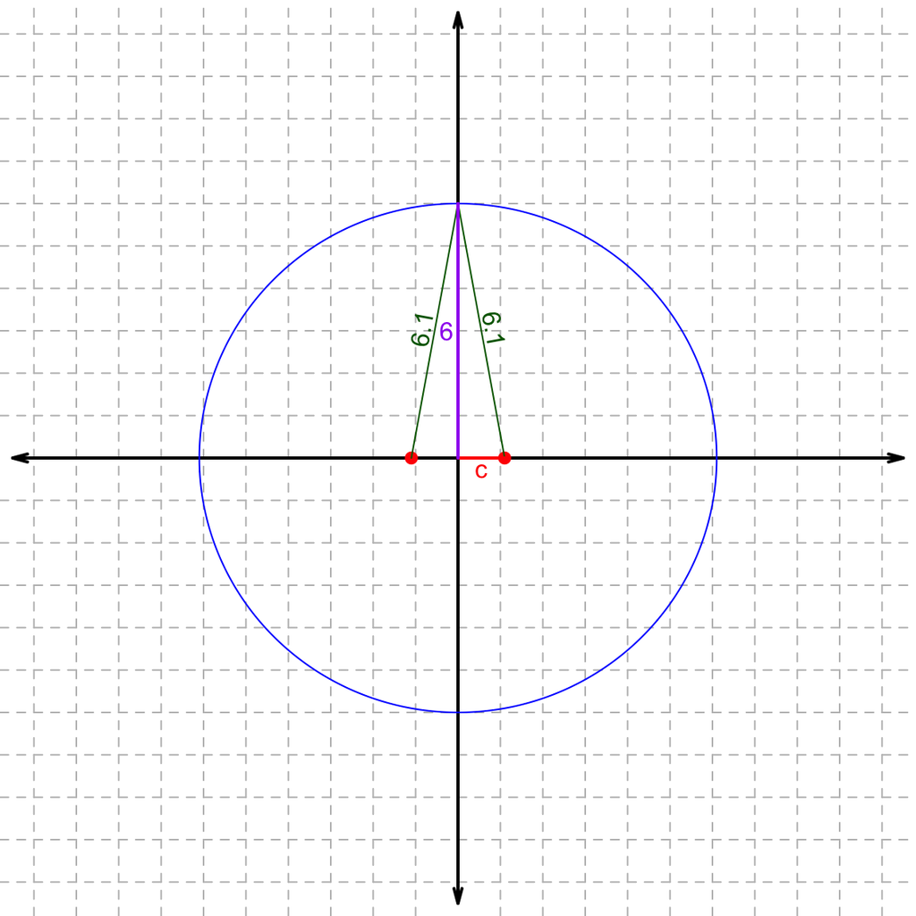

Notice the right triangle. We know two sides, and we are hoping to find the third side. Use [Pythagorean Equation](https://en.wikipedia.org/wiki/Pythagorean_theorem).

$$6^2+c^2=6.1^2$$

$$c^2=6.1^2-6^2$$

$$c^2=37.21-36$$

$$c^2=1.21$$

$$c=\sqrt{1.21}$$

$$c=1.1$$

The distance between the stakes is $2c$.

$$2c=2.2$$

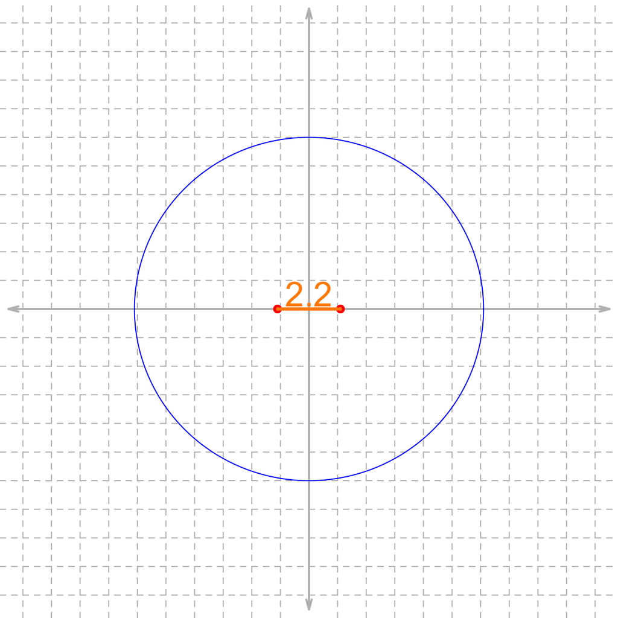

I guess I should also mention, that if $x^2+y^2=z^2$, then $(2x)^2+(2y)^2=(2z)^2$. This implies we can also get our answer without halving and doubling.

$$2b = \sqrt{(2a)^2-(2c)^2} =
\sqrt{12.2^2-2.2^2} = 12$$

# Meta-information